# Numerical Methods in Physics

## Lecture 2: Connecting the Dots

**Focus:**

- The Discrete vs. The Continuous
- Polynomial Interpolation & Runge's Phenomenon
- Splines (The Engineer's Choice)
- Spectral Interpolation (The Physicist's Choice)
- Gaussian Process Regression (The Data Scientist's Choice)
- Richardson Extrapolation (Getting something for nothing)

## 1. The Problem: The Space Between

**Physics is Continuous, Data is Discrete.**

- **Experiments:** You measure temperature at $t=1.0s$ and $t=2.0s$. What happened at $t=1.5s$?
- **Simulations:** You solve a PDE on a grid. You need the field value *between* grid points to track a particle.

**Interpolation** constructs a function $f(x)$ that passes exactly through a set of data points $(x_i, y_i)$. Closely associated: **Regression** (fitting), which minimizes error but doesn't necessarily hit the points.*

$\Rightarrow$ Key Question: What happens between our data points?

## 2. The Smoothness of the Universe: Why Nature is Piecewise Analytic

In mathematical physics, there is a recurring tension between smoothness and discontinuity. While mathematicians often study functions that are pathological or "rough," physical reality tends to settle into a specific structural category: Piecewise Analytic.

This document explores why the laws of physics favor analytic functions, where those functions break, and how we stitch the universe together at the seams.

### 2.1 The Engine of Analyticity

An analytic function is one that can be represented locally by a convergent Taylor series. If you know the derivatives of the function at a single point, you can predict its value everywhere within its radius of convergence.

#### The Source: Differential Equations

The primary reason nature is analytic is that the fundamental laws of physics are written in the language of Differential Equations with smooth coefficients.

- Classical Mechanics: Newton's Second Law (F=ma)
- Electromagnetism: Maxwell's Equations
- General Relativity: Einstein Field Equations

$\Rightarrow$ According to the **Cauchy-Kovalevskaya Theorem**, if you have a system of partial differential equations where the coefficients and initial conditions are analytic, the unique solution is also an analytic function.

#### The Implication

Because these laws govern the microscopic evolution of fields and particles, nature has a "memory." The state of a physical system at time t smoothly dictates its state at t+δt. There are no sudden surprises; the curve of a projectile or the orbit of a planet is perfectly smooth, possessing infinite derivatives.

### 2.2 The "Piecewise" Reality: Where the Smoothness Breaks

If the fundamental laws are analytic, why isn't the entire universe one single, infinite Taylor series? The answer lies in emergence, boundaries, and phase transitions.

#### A. Material Interfaces (The Boundary Condition)

In the macroscopic world, we deal with distinct objects. A steel ball floating in water represents two different domains of physics.

- **Inside the ball**: Density is constant (Analytic Region A).
- **Inside the water**: Density is constant (Analytic Region B).
- **The Interface**: At the surface, the density function jumps discontinuously.

We model this mathematically using Boundary Conditions. We treat the ball and the water as separate analytic "pieces" and stitch them together by matching their values (or stresses) at the boundary.

#### B. Shock Waves (The Hydrodynamic Jump)

In fluid dynamics, information travels at the speed of sound. If an object moves faster than sound, the fluid ahead of it cannot "know" it is coming. The smooth, analytic adjustment of air pressure becomes impossible.

- **The Result**: A Shock Wave. This is a mathematical discontinuity (or a near-discontinuity).
- **The Model**: We use the Rankine-Hugoniot conditions to connect the smooth flow ahead of the shock to the smooth flow behind the shock. The flow is analytic almost everywhere, but the shock itself is a singular "cut" in the domain.

#### C. Phase Transitions (Thermodynamic Singularities)

Perhaps the most profound example is thermodynamics. As you heat a block of ice, its properties evolve analytically. But at exactly $0^\circ$ C, the function breaks.

- The **Free Energy** function becomes non-analytic.
- Physical properties (like heat capacity) may approach infinity.
- **Why**: This represents a change in the symmetry of the material (from crystal lattice to chaotic liquid). The "Liquid Physics" series expansion cannot predict the "Ice Physics" behavior because the radius of convergence ends exactly at the melting point.

### 2.3 The Edge Case: Turbulence and Viscosity

Turbulent fluid flow is the ultimate test of this theory. At human scales, turbulence looks non-analytic—it appears rough, chaotic, and fractal.

However, nature imposes a hard limit called the Kolmogorov Microscale $(\eta)$:

$$\eta = \left(\dfrac{\nu^3}{\epsilon}\right)^{1/4}$$

(Where $\nu$ is viscosity and $\epsilon$ is the energy dissipation rate.)

- Above $\eta$: The flow acts like a fractal (Piecewise Rough).
- Below $\eta$: Viscosity dominates, smoothing out all gradients. The flow becomes strictly analytic.

Even in the most violent storm, if you zoom in to the micrometer scale, the velocity vectors are smooth, beautiful curves.

### 2.4 Summary

| Domain | Mathematical Nature | Reason |
| --- | --- | --- |
| Fundamental Fields | Analytic (Cω) | Governed by linear/non-linear PDEs. |
| Material Objects | Piecewise Analytic | Distinct materials separated by boundaries. |
| Phase Transitions | Singular | Thermodynamic non-analyticity at critical points. |
| Turbulence | Effectively Fractal | Multi-scale chaos, smoothed only at the micro-scale. |

## 3. Polynomial Interpolation

Given $N+1$ points, there exists a unique polynomial of degree $N$ that passes through all of them.

**The Lagrange Form:** $$ P(x) = \sum_{j=0}^{N} y_j L_j(x), \quad L_j(x) = \prod_{i \neq j} \frac{x - x_i}{x_j - x_i} $$

**The Trap:** High-degree polynomials are **dangerous**. They tend to oscillate wildly near the edges of the interval. This is known as **Runge's Phenomenon**.

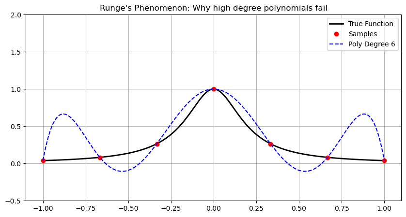

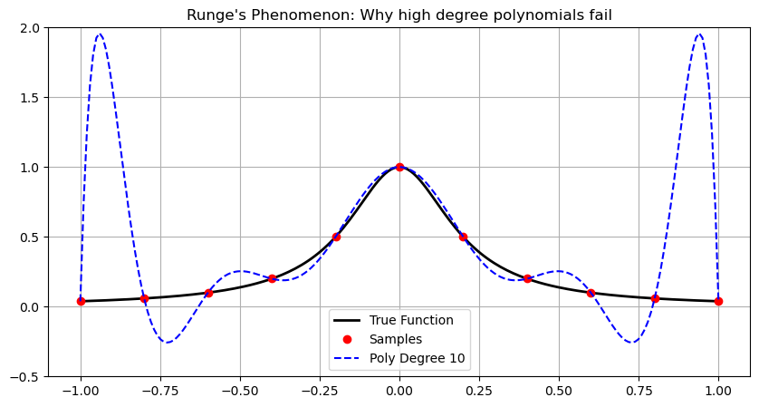

```python
import numpy as np
import matplotlib.pyplot as plt
from scipy.interpolate import lagrange


# The Runge Function: A nightmare for polynomials
def runge(x):
    return 1 / (1 + 25 * x**2)


# 1. Setup Data
x_fine = np.linspace(-1, 1, 200)

N = 7  # 11 points -> 10th degree polynomial
x_data = np.linspace(-1, 1, N)
y_data = runge(x_data)

# 2. Interpolate
poly = lagrange(x_data, y_data)
y_poly = poly(x_fine)

# 3. Plot
plt.figure(figsize=(10, 5))
plt.plot(x_fine, runge(x_fine), "k-", label="True Function", lw=2)
plt.plot(x_data, y_data, "ro", label="Samples")
plt.plot(x_fine, y_poly, "b--", label=f"Poly Degree {N-1}")
plt.legend()
plt.title("Runge's Phenomenon: Why high degree polynomials fail")
plt.ylim(-0.5, 2.0)
plt.grid(True)


# 1. Setup Data
N = 11  # 11 points -> 10th degree polynomial
x_data = np.linspace(-1, 1, N)
y_data = runge(x_data)

# 2. Interpolate
poly = lagrange(x_data, y_data)
y_poly = poly(x_fine)

# 3. Plot
plt.figure(figsize=(10, 5))
plt.plot(x_fine, runge(x_fine), "k-", label="True Function", lw=2)
plt.plot(x_data, y_data, "ro", label="Samples")
plt.plot(x_fine, y_poly, "b--", label=f"Poly Degree {N-1}")
plt.legend()
plt.title("Runge's Phenomenon: Why high degree polynomials fail")
plt.ylim(-0.5, 2.0)
plt.grid(True)
```

## 4. The Solution: Splines

Instead of one giant global polynomial, we use many tiny, low-degree polynomials glued together.

### 4.1 What Makes Cubic Splines Special: The Drafting Spline

In numerical analysis and computer-aided design, cubic splines are ubiquitous. While they are often introduced simply as "piecewise cubic polynomials with continuous second derivatives," their true mathematical elegance lies in a variational property.

Among all sufficiently smooth functions that pass through a given set of data points, the natural cubic spline is the one that is the "smoothest," in the specific sense that it minimizes the total bending energy.

Before computers, draftsmen used a physical tool called a spline to draw smooth curves through a set of fixed points (called "ducks" or weights). This spline was a thin, flexible strip of wood or metal.

##### 4.1.1 Bending Energy

From the Euler-Bernoulli beam theory, the strain energy $E$ stored in an elastic beam of length $L$ is proportional to the integral of the square of its curvature $\kappa$ along the arclength $s$:

$$E \propto \int_0^L \kappa(s)^2 \, ds$$

If the beam is forced to pass through specific points (the weights) but is otherwise free, nature dictates that it will assume a shape that minimizes this internal energy.

##### 4.1.2 Mathematical Linearization

Let the shape of the beam be described by a function $y = f(x)$ on the interval $[a, b]$. The mathematical definition of curvature at a point $x$ is:

$$\kappa(x) = \frac{f''(x)}{\left( 1 + [f'(x)]^2 \right)^{3/2}}$$

The arclength differential is $ds = \sqrt{1 + [f'(x)]^2} \, dx$. Substituting these into the energy functional yields:

$$E(f) \propto \int_a^b \frac{[f''(x)]^2}{\left( 1 + [f'(x)]^2 \right)^3} \sqrt{1 + [f'(x)]^2} \, dx = \int_a^b \frac{[f''(x)]^2}{\left( 1 + [f'(x)]^2 \right)^{5/2}} \, dx$$

This objective function is highly non-linear and difficult to minimize directly. However, if we assume the "small slope" approximation (commonly used in beam theory), where $|f'(x)| \ll 1$, we can approximate:

$$1 + [f'(x)]^2 \approx 1$$

Under this assumption, the denominators vanish, and $ds \approx dx$. The energy functional simplifies to the linearized bending energy:

$$J(f) = \int_a^b [f''(x)]^2 \, dx$$

The Claim: The function that minimizes $J(f)$ subject to interpolation constraints is exactly the Natural Cubic Spline.

#### 4.1.3 The Minimization Theorem

We now state the theorem formally.

Theorem: Let $a = x_0 < x_1 < \dots < x_n = b$ be a set of nodes, and let $y_0, y_1, \dots, y_n$ be a set of corresponding values. Let $\mathcal{F}$ be the class of all functions $f(x)$ defined on $[a, b]$ such that:

1. $f(x)$ is twice continuously differentiable ($f \in C^2[a, b]$).
2. $f(x)$ interpolates the data: $f(x_i) = y_i$ for $i = 0, \dots, n$.

Let $S(x)$ be the natural cubic spline interpolating the same data. "Natural" implies the boundary conditions $S''(a) = 0$ and $S''(b) = 0$.

Then, for any $f \in \mathcal{F}$:

$$\int_a^b [S''(x)]^2 \, dx \le \int_a^b [f''(x)]^2 \, dx$$

Equality holds if and only if $f(x) = S(x)$ (assuming $n \ge 1$).

#### 4.1.4 Detailed Proof

##### Step 1: Define the Discrepancy Function

Let $g(x)$ be the difference between the arbitrary interpolant $f(x)$ and the cubic spline $S(x)$:

$$g(x) = f(x) - S(x)$$

Rearranging, we have $f(x) = S(x) + g(x)$.

Properties of $g(x)$:

1. Since both $f$ and $S$ interpolate the data points $y_i$, their difference is zero at the nodes: $$g(x_i) = f(x_i) - S(x_i) = y_i - y_i = 0 \quad \text{for } i = 0, \dots, n$$
2. Since $f, S \in C^2[a, b]$, $g \in C^2[a, b]$.

##### Step 2: Expand the Energy Functional

Substitute $f = S + g$ into the functional $J(f)$:

$$\begin{aligned} \int_a^b [f''(x)]^2 \, dx &= \int_a^b [S''(x) + g''(x)]^2 \, dx \\ &= \int_a^b \left( [S''(x)]^2 + 2S''(x)g''(x) + [g''(x)]^2 \right) \, dx \\ &= \int_a^b [S''(x)]^2 \, dx + 2 \int_a^b S''(x)g''(x) \, dx + \int_a^b [g''(x)]^2 \, dx \end{aligned}$$

To prove that $S(x)$ is the minimizer, we need to show that the "cross-term" is zero or positive:

$$\int_a^b S''(x)g''(x) \, dx \geq 0$$

##### Step 3: Analyze the Cross-Term

We evaluate $I = \int_a^b S''(x)g''(x) \, dx$ using Integration by Parts. Let:

- $u = S''(x)$
- $dv = g''(x) \, dx \implies v = g'(x)$

$$I = \left[ S''(x)g'(x) \right]_a^b - \int_a^b S'''(x)g'(x) \, dx$$

##### Boundary Term Analysis

The first term is:

$$\left[ S''(x)g'(x) \right]_a^b = S''(b)g'(b) - S''(a)g'(a)$$

Since $S(x)$ is a natural cubic spline, by definition:

$$S''(b) = 0 \quad \text{and} \quad S''(a) = 0$$

Therefore, the boundary term vanishes entirely.

(Note: If we were using Clamped Splines instead, we would require $f'(a)=S'(a)$ and $f'(b)=S'(b)$, which would imply $g'(a)=0$ and $g'(b)=0$, also making this term vanish.)

##### Integral Term Analysis

We are left with:

$$I = - \int_a^b S'''(x)g'(x) \, dx$$

The function $S(x)$ is a cubic spline. This means that on every sub-interval $[x_i, x_{i+1}]$, $S(x)$ is a cubic polynomial. Consequently:

- $S'(x)$ is a quadratic.
- $S''(x)$ is linear.
- $S'''(x)$ is constant on each sub-interval.

Let $c_i$ be the constant value of $S'''(x)$ on the interval $(x_i, x_{i+1})$. We can split the integral over the sub-intervals:

$$I = - \sum_{i=0}^{n-1} \int_{x_i}^{x_{i+1}} S'''(x)g'(x) \, dx = - \sum_{i=0}^{n-1} \int_{x_i}^{x_{i+1}} c_i g'(x) \, dx$$

Since $c_i$ is constant relative to the integral:

$$I = - \sum_{i=0}^{n-1} c_i \int_{x_i}^{x_{i+1}} g'(x) \, dx$$

By the Fundamental Theorem of Calculus, $\int_{x_i}^{x_{i+1}} g'(x) \, dx = g(x_{i+1}) - g(x_i)$.

$$I = - \sum_{i=0}^{n-1} c_i \left[ g(x_{i+1}) - g(x_i) \right]$$

Recall Property 1 of $g(x)$: it is zero at every node $x_i$.

$$g(x_{i+1}) = 0 \quad \text{and} \quad g(x_i) = 0$$

Therefore, every term in the summation is zero.

$$I = 0$$

##### Step 4: Final Inequality

Returning to our expansion in Step 2:

$$\int_a^b [f''(x)]^2 \, dx = \int_a^b [S''(x)]^2 \, dx + \underbrace{2(0)}_{\text{Cross-term}} + \int_a^b [g''(x)]^2 \, dx$$

$$\int_a^b [f''(x)]^2 \, dx = \int_a^b [S''(x)]^2 \, dx + \int_a^b [g''(x)]^2 \, dx$$

Since the integrand $[g''(x)]^2$ is non-negative everywhere, the integral $\int_a^b [g''(x)]^2 \, dx \ge 0$.

Thus:

$$\int_a^b [f''(x)]^2 \, dx \ge \int_a^b [S''(x)]^2 \, dx$$

##### Step 5: Uniqueness

When does equality hold? Equality holds only if $\int_a^b [g''(x)]^2 \, dx = 0$. Since $g''(x)$ is continuous, this implies $g''(x) = 0$ for all $x \in [a, b]$. If the second derivative is zero, $g(x)$ must be a linear function: $g(x) = mx + c$.

However, we know that $g(x_0) = 0$ and $g(x_n) = 0$ (and zero at all intermediate points). A line that passes through zero at multiple points (assuming distinct nodes) must be identically zero.

$$g(x) \equiv 0 \implies f(x) = S(x)$$

#### 4.1.6 Conclusion

We have proven that the Natural Cubic Spline is the unique function that minimizes $\int (f'')^2 dx$ among all $C^2$ interpolants.

This explains why cubic splines appear "smooth" to the human eye and do not exhibit the wild oscillations (Runge's phenomenon) often seen in high-degree polynomial interpolation. They are physically relaxed systems.

### 4.2 Derivation of piece-wise cubic splines

#### Mathematical Requirements:

- Piecewise cubic polynomials
- Continuous function values ($C^0$)
- Continuous first derivatives ($C^1$)
- Continuous second derivatives ($C^2$)
- Use a cubic polynomial ($ax^3+bx^2+cx+d$) between every pair of points.
- **Constraints:**
  1. Pass through the points.
  2. Continuous first derivative ($f'$).
  3. Continuous second derivative ($f''$).

#### 4.2.1 Setup and Notation

We now derive the cubic spline system for uniform spacing $h$. This derivation reveals why it connects directly to central differences. We have data points:

$$(x_0, f_0), (x_1, f_1), \dots, (x_n, f_n)$$

with uniform spacing: $x_{i+1} - x_i = h$.

#### 4.2.2 using Hermite polynomials

On $[x_i, x_{i+1}]$, use Hermite cubic with values $f_i, f_{i+1}$.

$$S_i(x) = f_i H_0(t) + f_{i+1} H_1(t) + m_i h \tilde{H}_0(t) + m_{i+1} h \tilde{H}_1(t)$$

where $t = \frac{x - x_i}{h} \in [0, 1]$, and:

1. Let $m_i = S'(x_i)$ be the unknown slope at node $x_i$.
2. $H_0(t) = 1 - 3t^2 + 2t^3$ (Value basis: 1 at start, 0 at end)
3. $H_1(t) = 3t^2 - 2t^3$ (Value basis: 0 at start, 1 at end)
4. $\tilde{H}_0(t) = t - 2t^2 + t^3$ (Slope basis: slope 1 at start, 0 at end)
5. $\tilde{H}_1(t) = -t^2 + t^3$ (Slope basis: slope 0 at start, slope 1 at end)

Second derivative:

$$S_i''(x) = \frac{1}{h^2}[f_i H_0''(t) + f_{i+1} H_1''(t) + m_i h \tilde{H}_0''(t) + m_{i+1} h \tilde{H}_1''(t)]$$

Compute derivatives:

$$H_0''(t) = -6 + 12t, \quad H_1''(t) = 6 - 12t$$

$$\tilde{H}_0''(t) = -4 + 6t, \quad \tilde{H}_1''(t) = -2 + 6t$$

At $t=0$ (left endpoint $x_i$):

$$S_i''(x_i) = \frac{1}{h^2}[f_i(-6) + f_{i+1}(6) + m_i h(-4) + m_{i+1} h(-2)]$$

$$S_i''(x_i) = \frac{6(f_{i+1} - f_i)}{h^2} - \frac{4m_i + 2m_{i+1}}{h}$$

At $t=1$ (right endpoint $x_{i+1}$):

$$S_i''(x_{i+1}) = \frac{1}{h^2}[f_i(6) + f_{i+1}(-6) + m_i h(2) + m_{i+1} h(4)]$$

$$S_i''(x_{i+1}) = \frac{6(f_i - f_{i+1})}{h^2} + \frac{2m_i + 4m_{i+1}}{h}$$

#### 4.2.3 Continuity Condition

For $C^2$ continuity at $x_i$:

$$S_{i-1}''(x_i) = S_i''(x_i)$$

But $S_{i-1}''(x_i)$ is $S_{i-1}''$ at its right endpoint $t=1$:

$$S_{i-1}''(x_i) = \frac{6(f_{i-1} - f_i)}{h^2} + \frac{2m_{i-1} + 4m_i}{h}$$

And $S_i''(x_i)$ is at its left endpoint $t=0$:

$$S_i''(x_i) = \frac{6(f_{i+1} - f_i)}{h^2} - \frac{4m_i + 2m_{i+1}}{h}$$

Equate them:

$$\frac{6(f_{i-1} - f_i)}{h^2} + \frac{2m_{i-1} + 4m_i}{h} = \frac{6(f_{i+1} - f_i)}{h^2} - \frac{4m_i + 2m_{i+1}}{h}$$

#### 4.2.4 Rearrange to Final Form

Multiply by $h$:

$$\frac{6(f_{i-1} - f_i)}{h} + 2m_{i-1} + 4m_i = \frac{6(f_{i+1} - f_i)}{h} - 4m_i - 2m_{i+1}$$

Bring $m$ terms to left, $f$ terms to right:

$$2m_{i-1} + 4m_i + 4m_i + 2m_{i+1} = \frac{6(f_{i+1} - f_i)}{h} - \frac{6(f_{i-1} - f_i)}{h}$$

$$2m_{i-1} + 8m_i + 2m_{i+1} = \frac{6}{h}(f_{i+1} - f_i - f_{i-1} + f_i)$$

$$2m_{i-1} + 8m_i + 2m_{i+1} = \frac{6}{h}(f_{i+1} - f_{i-1})$$

Divide by 2:

$$m_{i-1} + 4m_i + m_{i+1} = \frac{3}{h}(f_{i+1} - f_{i-1})$$

#### 4.2.5 Result

We now have the tridiagonal system:

$$m_{i-1} + 4m_i + m_{i+1} = \frac{3}{h}(f_{i+1} - f_{i-1}), \quad i = 1, \dots, n-1$$

Notice the right side:

$$\frac{3}{h}(f_{i+1} - f_{i-1}) = 3 \times \left[\frac{f_{i+1} - f_{i-1}}{2h}\right] \times 2$$

where $\frac{f_{i+1} - f_{i-1}}{2h}$ is the central difference approximation for $f'(x_i)$!

#### 4.2.6 Matrix Form

For interior points $i = 1, \dots, n-1$:

$$\begin{bmatrix} 4 & 1 & & & \\ 1 & 4 & 1 & & \\ & 1 & 4 & 1 & \\ & & \ddots & \ddots & \ddots \\ & & & 1 & 4 \end{bmatrix} \begin{bmatrix} m_1 \\ m_2 \\ \vdots \\ m_{n-1} \end{bmatrix} = \frac{3}{h} \begin{bmatrix} f_2 - f_0 \\ f_3 - f_1 \\ \vdots \\ f_n - f_{n-2} \end{bmatrix}$$

Plus boundary conditions for $m_0$ and $m_n$.

#### 4.2.7 Insights from This Derivation

$\Rightarrow$ The right-hand side involves central differences explicitly

$\Rightarrow$ Each equation couples three consecutive slopes, ensuring smooth curvature

$\Rightarrow$ The system must be solved globally (all $m_i$ simultaneously)

$\Rightarrow$ The [1, 4, 1] pattern emerges naturally from Hermite cubic basis functions

$\Rightarrow$ This explains why cubic spline derivatives are smoother than simple finite differences: they're obtained by solving a tridiagonal system where each local central difference is "averaged" with its neighbors through the [1, 4, 1] weighting.

```python
import numpy as np

def derive_cubic_spline_system(x, y):
    """
    Derive and solve the cubic spline system
    Returns: slopes m_i at each point
    """
    n = len(x)
    h = x[1] - x[0]  # uniform spacing

    # Tridiagonal matrix: [1, 4, 1] on main diagonals
    A = np.zeros((n - 2, n - 2))
    for i in range(n - 2):
        A[i, i] = 4
        if i > 0:
            A[i, i - 1] = 1
        if i < n - 3:
            A[i, i + 1] = 1

    # Right-hand side: 3/h * (f_{i+1} - f_{i-1})
    b = np.zeros(n - 2)
    for i in range(1, n - 1):
        b[i - 1] = (3 / h) * (y[i + 1] - y[i - 1])

    # Solve for interior slopes
    m_interior = np.linalg.solve(A, b)

    # For boundaries, use one-sided differences
    m = np.zeros(n)
    m[1:-1] = m_interior
    m[0] = (y[1] - y[0]) / h  # Forward difference
    m[-1] = (y[-1] - y[-2]) / h  # Backward difference

    return m


# Test the derivation
x_test = np.linspace(0, 2 * np.pi, 7)
y_test = np.sin(x_test)
m_spline = derive_cubic_spline_system(x_test, y_test)

# Compare with finite differences
m_fd = np.zeros_like(y_test)
m_fd[0] = (y_test[1] - y_test[0]) / (x_test[1] - x_test[0])
m_fd[-1] = (y_test[-1] - y_test[-2]) / (x_test[-1] - x_test[-2])
m_fd[1:-1] = (y_test[2:] - y_test[:-2]) / (2 * (x_test[1] - x_test[0]))

print("Slopes at interior points:")
for i in range(1, len(x_test) - 1):
    print(f"x={x_test[i]:.3f}: FD={m_fd[i]:.6f}, Spline={m_spline[i]:.6f}")
```

```
Slopes at interior points:
x=1.047: FD=0.413497, Spline=0.763378
x=2.094: FD=-0.413497, Spline=-0.572534
x=3.142: FD=-0.826993, Spline=-0.954223
x=4.189: FD=-0.413497, Spline=-0.572534
x=5.236: FD=0.413497, Spline=0.763378
```

#### 4.2.8 Example

This code demonstrates Runge's Phenomenon and manually implements the Natural Cubic Spline solver derived in Section 4.

The goal is to solve the linear system $A \mathbf{m} = \mathbf{b}$ where $\mathbf{m}$ is the vector of slopes.

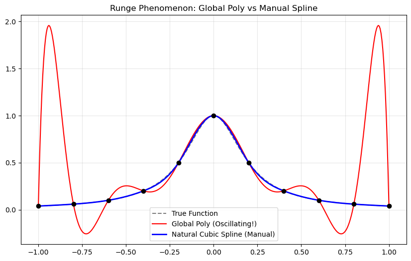

```python
import numpy as np
import matplotlib.pyplot as plt
from scipy.interpolate import lagrange


def solve_natural_spline(x_nodes, y_nodes):
    """
    Solves for the slopes 'm' for a natural cubic spline
    given nodes (x, y) with uniform spacing h.
    """
    n = len(x_nodes) - 1
    h = x_nodes[1] - x_nodes[0]

    # 1. Build the Tridiagonal System A * m = b
    # Dimension is n+1 (indices 0 to n)
    A = np.zeros((n + 1, n + 1))
    b = np.zeros(n + 1)

    # Interior Points (Equation from Sec 4.5): m_{i-1} + 4m_i + m_{i+1} = 3/h * (y_{i+1} - y_{i-1})
    for i in range(1, n):
        A[i, i - 1] = 1
        A[i, i] = 4
        A[i, i + 1] = 1
        b[i] = (3 / h) * (y_nodes[i + 1] - y_nodes[i - 1])

    # Boundary Conditions: Natural Spline -> S''(x_0) = 0, S''(x_n) = 0
    # Derived conditions:
    # 2*m_0 + m_1 = 3/h * (y_1 - y_0)
    # m_{n-1} + 2*m_n = 3/h * (y_n - y_{n-1})

    A[0, 0] = 2
    A[0, 1] = 1
    b[0] = (3 / h) * (y_nodes[1] - y_nodes[0])

    A[n, n - 1] = 1
    A[n, n] = 2
    b[n] = (3 / h) * (y_nodes[n] - y_nodes[n - 1])

    # 2. Solve the linear system
    m = np.linalg.solve(A, b)
    return m


def evaluate_spline(x_eval, x_nodes, y_nodes, m):
    """
    Evaluates the spline at x_eval points using Hermite basis (Sec 4.2).
    """
    y_eval = []
    h = x_nodes[1] - x_nodes[0]
    n = len(x_nodes) - 1

    for x in x_eval:
        # Find which interval [x_i, x_{i+1}] x falls into
        if x < x_nodes[0]:
            i = 0
        elif x >= x_nodes[-1]:
            i = n - 1
        else:
            i = int((x - x_nodes[0]) // h)

        # Local parameter t in [0, 1]
        t = (x - x_nodes[i]) / h

        # Hermite Basis Functions
        H0 = 1 - 3 * t**2 + 2 * t**3
        H1 = 3 * t**2 - 2 * t**3
        H_hat0 = t - 2 * t**2 + t**3
        H_hat1 = -(t**2) + t**3

        # Interpolate
        val = (
            y_nodes[i] * H0
            + y_nodes[i + 1] * H1
            + m[i] * h * H_hat0
            + m[i + 1] * h * H_hat1
        )
        y_eval.append(val)

    return np.array(y_eval)


# --- Main Demo ---


# 1. Runge Function
def runge_function(x):
    return 1 / (1 + 25 * x**2)


# 2. Nodes
x_nodes = np.linspace(-1, 1, 11)
y_nodes = runge_function(x_nodes)

# 3. Solve Spline manually
slopes = solve_natural_spline(x_nodes, y_nodes)

# 4. Evaluation
x_dense = np.linspace(-1, 1, 400)
y_spline = evaluate_spline(x_dense, x_nodes, y_nodes, slopes)

# 5. Polynomial for comparison
poly = lagrange(x_nodes, y_nodes)
y_poly = poly(x_dense)

# 6. Plot
plt.figure(figsize=(10, 6))
plt.plot(x_dense, runge_function(x_dense), "k--", alpha=0.5, label="True Function")
plt.plot(x_dense, y_poly, "r-", label="Global Poly (Oscillating!)")
plt.plot(x_dense, y_spline, "b-", linewidth=2, label="Natural Cubic Spline (Manual)")
plt.plot(x_nodes, y_nodes, "ko")
plt.legend()
plt.title("Runge Phenomenon: Global Poly vs Manual Spline")
plt.grid(True, alpha=0.3)
plt.show()
```

**USing scipy directly**

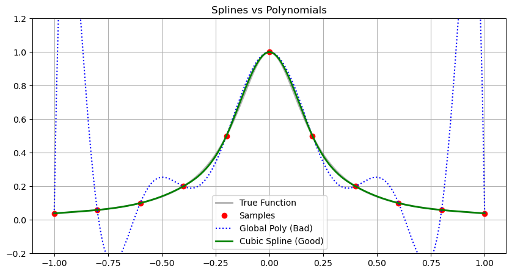

```python
from scipy.interpolate import CubicSpline

# The Runge Function: A nightmare for polynomials
def runge(x):
    return 1 / (1 + 25 * x**2)

# 1. Setup Data
x_fine = np.linspace(-1, 1, 200)

N = 11  # 11 points -> 10th degree polynomial
x_data = np.linspace(-1, 1, N)
y_data = runge(x_data)

# 1. Create Spline
cs = CubicSpline(x_data, y_data)

# 2. Plot comparison
plt.figure(figsize=(10, 5))
plt.plot(x_fine, runge(x_fine), "k-", label="True Function", lw=2, alpha=0.3)
plt.plot(x_data, y_data, "ro", label="Samples")
# evaluate the polynomial on the same x grid as x_fine (lengths must match)
plt.plot(x_fine, poly(x_fine), "b:", label="Global Poly (Bad)")
plt.plot(x_fine, cs(x_fine), "g-", label="Cubic Spline (Good)", lw=2)

plt.legend()
plt.title("Splines vs Polynomials")
plt.ylim(-0.2, 1.2)
plt.grid(True)
```

## 5. Spectral Interpolation

If your physics is periodic (waves, lattice vibrations, orbits) or at least smooth, **Taylor polynomials are the wrong basis.**

Use **Sines and Cosines** (Fourier Series). Or **orthogonal polynomials**.

### 5.1 Introduction: The Choice of Basis

In computational physics and numerical analysis, the choice of basis functions determines the convergence rate and accuracy of your simulation. We face a fundamental problem: we have a discrete set of data points, $x[n]$, and we need to reconstruct the underlying continuous function $f(x)$ everywhere.

The "Spectral" philosophy is to use global basis functions rather than local ones (like finite elements or splines). This choice is dictated by the physical boundary conditions:

1. Periodic Physics (Waves, Orbits): Use Fourier Series (Sines/Cosines).
   - Example: Crystal lattices (phonons), planetary orbits, ring resonators.
2. Bounded/Non-Periodic Physics (Boxes, Pipes): Use Orthogonal Polynomials (Chebyshev/Legendre).
   - Example: Flow in a pipe (no-slip walls), Quantum particle in a box.

### 5.2: Periodic Systems (Fourier)

#### 5.2.1 The Foundation: Discrete Fourier Transform (DFT)

For a continuous function $x(t)$, the continuous Fourier transform is defined as an integral:

$$X(f) = \int_{-\infty}^{\infty} x(t) e^{-i 2\pi f t} dt$$

**Discretization**

Computers cannot do integrals. We approximate this by:

1. Sampling Time: We only measure $x(t)$ at $N$ discrete points $t_n = n \Delta t$.
2. Truncating Bounds: We sum over a finite window of time $T = N \Delta t$.
3. Discretizing Frequency: We only evaluate $X(f)$ at discrete frequencies $f_k = k \frac{1}{T}$.
4. IIf $x(t)$ is periodic, equispaced grids work perfectly.

This turns the integral into the **Riemann Sum** that defines the DFT:

$$X[k] \approx \sum_{n=0}^{N-1} x[n] e^{-i 2\pi (k \Delta f) (n \Delta t)} \Delta t$$

Dropping the scaling factor $\Delta t$, we arrive at the standard definition:

$$X[k] = \sum_{n=0}^{N-1} x[n] e^{-i \frac{2\pi}{N} k n}$$

The sequence can be perfectly reconstructed using the Inverse DFT (IDFT): The sequence can be perfectly reconstructed using the Inverse DFT (IDFT):

$$x[n] = \frac{1}{N} \sum_{k=0}^{N-1} X[k] e^{i \frac{2\pi}{N} k n}$$

**Insight (Reciprocal Space):** In Solid State Physics, $x[n]$ represents the atomic positions in real space. $X[k]$ represents the Reciprocal Lattice. The index $k$ corresponds to the crystal momentum (wavevector). The DFT allows us to solve differential equations (like the Schrödinger equation) much faster because differentiation in real space becomes simple multiplication in reciprocal space ($\partial_x \to ik$).

**Key Orthogonality Property:** The exponentials form an orthogonal basis. The inner product sum is:

$$\sum_{n=0}^{N-1} e^{i \frac{2\pi}{N} (k-l) n} = \begin{cases} N & \text{if } k=l \\ 0 & \text{if } k \neq l \end{cases}$$

#### 5.2.2 Interpolation (Resampling) Method: Zero Padding

We wish to interpolate our sequence $x[n]$ of length $N$ to a denser sequence $y[m]$ of length $M$ (where $M > N$).

##### **The Algorithm**

1. Analysis: Compute the DFT of the original $N$ points.
2. Shift: Center the DC component so frequencies run from $-N/2$ to $+N/2$.
3. Pad: Append exactly $M-N$ zeros to the high-frequency **ends** of the spectrum.
   - This extends the total length of the frequecny array from $N$ to $M$.
   - Why: We assume the "energy" or information at higher frequencies (which we did't measure) is exactly zero.
4. Synthesis: Compute the Inverse DFT.

##### **Implementation notes for Padding**

**The "Standard" DFT Layout vs. The "Shifted" Layout**

While we often visualize spectra as symmetric (centered at 0), standard FFT algorithms output an array indexed from 0 to N-1 with a specific layout:

1. **Index 0**: The DC Component (Frequency 0).
2. **Indices 1 to N/2 - 1**: Positive Frequencies ($0 < f < f_{Nyquist}$).
3. **Index N/2**: The Nyquist Frequency (Highest measurable frequency).
4. **Indices N/2 + 1 to N - 1**: Negative Frequencies.

**Why are negative frequencies at the end?** Because of periodicity! $e^{-i x}$ is mathematically identical to $e^{i (2\pi - x)}$. The computer stores negative frequencies as "large positive" frequencies.

**Visualizing the Padding**

When we pad with zeros to increase resolution, we are adding "zero energy" at the **highest frequencies**.

In the **Standard Layout** (what the computer sees), the "High Frequencies" are in the **middle** of the array (around $N/2$). The "Low Frequencies" (DC and slightly negative) are at the **edges** (0 and N-1).

Therefore, to pad correctly, we must split the array in the middle and insert zeros there.

**Original Array ($N$):** [ DC | Pos Freqs | Nyquist | Neg Freqs ]

**Padded Array ($M$):** [ DC | Pos Freqs | 0 ... 0 ... 0 | Neg Freqs ] *(Zeros inserted here, in the "middle")*

Mathematically, the new array $Y[k]$ of length $M$ is constructed as:

$$Y[k] = \begin{cases} X[k] & 0 \le k < N/2 \quad \text{(Positive Frequencies)} \\ 0 & N/2 \le k < M - N/2 \quad \text{(The Zero Pad)} \\ X[k - (M-N)] & M - N/2 \le k < M \quad \text{(Negative Frequencies)} \end{cases}$$

**Physics Insight (Band-Limited Signals):** This is equivalent to a "Brick Wall Low-Pass Filter." By forcing high frequencies to zero, you are stating that the signal has a finite bandwidth. In Quantum Mechanics, for eg, this would be analogous to a truncated basis set approximation—assuming the wavefunction has no contribution from energy eigenstates above a certain cutoff $E_{max}$.

#### 5.2.3 Why does Fourier interpolation work?

Why does zero-padding to length $M$ result in smooth interpolation of $N$ points? We prove this by substituting the DFT definition into the reconstruction formula evaluated at the finer grid resolution.

We assume $N$ is odd for symmetry, with $k$ ranging from $-(N-1)/2$ to $(N-1)/2$. We wish to find interpolated values at $M$ new sample points.

**Step 1: Continuous Reconstruction**

First, consider the continuous interpolant $x(t)$ constructed from the $N$ original Fourier coefficients $X[k]$. This represents the band-limited function implied by the zero-padding.

**Step 2: Substitution** Substitute the definition of $X[k] = \sum_{n=0}^{N-1} x[n] e^{-i \frac{2\pi}{N} k n}$:

$$x(t) = \frac{1}{N} \sum_{k=-(N-1)/2}^{(N-1)/2} \left[ \sum_{n=0}^{N-1} x[n] e^{-i \frac{2\pi}{N} k n} \right] e^{i \frac{2\pi}{N} k t}$$

**Step 3: Swap Summation Order** We bring the sum over $n$ outside:

$$x(t) = \sum_{n=0}^{N-1} x[n] \underbrace{\left[ \frac{1}{N} \sum_{k=-(N-1)/2}^{(N-1)/2} e^{i \frac{2\pi}{N} k (t-n)} \right]}_{\text{Kernel } D_N(t-n)}$$

**Step 4: Evaluating the Geometric Series (The Kernel)** Let $\phi = \frac{2\pi}{N}(t-n)$. The kernel term is a geometric series sum:

$$S = \sum_{k=-K}^{K} e^{i k \phi} \quad \text{where } K = \frac{N-1}{2}$$

Recall the geometric sum formula $\sum_{k=A}^B r^k = \frac{r^A - r^{B+1}}{1-r}$. Here $r = e^{i\phi}$.

$$S = \frac{e^{-i K \phi} - e^{i (K+1) \phi}}{1 - e^{i\phi}}$$

Multiply numerator and denominator by $e^{-i \phi/2}$ to create sines:

$$S = \frac{e^{-i(K+1/2)\phi} - e^{i(K+1/2)\phi}}{e^{-i\phi/2} - e^{i\phi/2}}$$

Using Euler's formula ($e^{-ix} - e^{ix} = -2i\sin(x)$):

$$S = \frac{-2i \sin((K+1/2)\phi)}{-2i \sin(\phi/2)} = \frac{\sin(N \phi / 2)}{\sin(\phi/2)}$$

Substituting $\phi = \frac{2\pi}{N}(t-n)$:

$$D_N(t-n) = \frac{1}{N} \frac{\sin\left( \pi (t-n) \right)}{\sin\left( \frac{\pi}{N} (t-n) \right)}$$

**Therefore:**

$$x(t) = \sum_{n=0}^{N-1} x[n] \cdot D_N(t-n)$$

**Step 5: The Connection to Grid M** The zero-padding algorithm (taking an $M$-point IFFT) is mathematically equivalent to evaluating this continuous function $x(t)$ at the fractional time steps of the finer grid:

$$t \rightarrow m \cdot \frac{N}{M} \quad \text{for } m = 0, \dots, M-1$$

Substituting this into our result gives the explicit interpolation formula mapping $N$ input points to $M$ output points:

$$y[m] = \sum_{n=0}^{N-1} x[n] \cdot \frac{1}{N} \frac{\sin\left( \pi (m \frac{N}{M} - n) \right)}{\sin\left( \frac{\pi}{N} (m \frac{N}{M} - n) \right)}$$

**Conclusion:** By padding with zeros to size $M$, we are strictly performing a convolution of the original $N$ data points with the Dirichlet Kernel, evaluated at the new sample rate $M$.

**Insight (Diffraction):** The function $D_N(t)$ is the Dirichlet Kernel. In Optics, this function describes the Diffraction Pattern of a Diffraction Grating with $N$ slits.

Interpolation is convolving the discrete time samples with sinc --> leading to a smooth curve.

#### 5.2.4 Examples of **Periodic Interpolation (Fourier Zero-Padding)**

This demonstrates how zero-padding in the frequency domain results in "smooth" interpolation in the time domain, effectively implementing the Dirichlet kernel convolution.

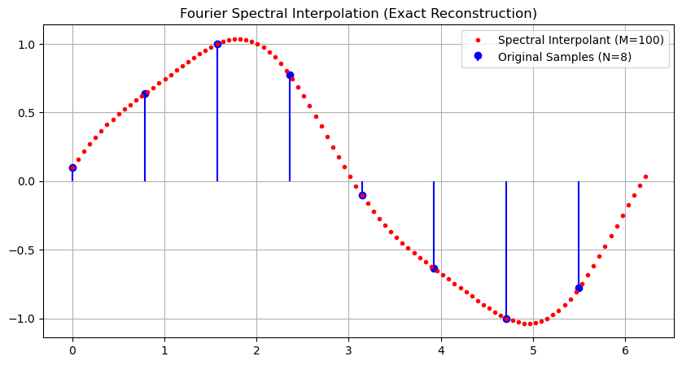

```python
import numpy as np
import matplotlib.pyplot as plt
from scipy.fft import fft, ifft, fftfreq

def spectral_interpolate(y_data, M_new):
    """
    Interpolates 1D periodic data y_data of length N to length M_new
    using Fourier zero-padding.
    """
    N = len(y_data)

    # 1. ANALYSIS: Compute FFT
    Y_k = fft(y_data)

    # 2. SHIFT: Center the zero-frequency component
    # This makes the array run from -freq_max to +freq_max
    Y_k_shifted = np.fft.fftshift(Y_k)

    # 3. PAD: Create a larger array of zeros
    Y_padded = np.zeros(M_new, dtype=complex)

    # Calculate indices to place the original frequencies in the center
    start_idx = (M_new - N) // 2
    Y_padded[start_idx : start_idx + N] = Y_k_shifted

    # 4. SYNTHESIS: Inverse FFT
    # Note: Must shift back before IFFT and scale by (M/N) to preserve amplitude
    Y_padded_unshifted = np.fft.ifftshift(Y_padded)
    y_interp = ifft(Y_padded_unshifted) * (M_new / N)

    return y_interp

# --- Live Demo ---
# Create a coarse, periodic signal (e.g., 8 points of a sine wave)
N = 8
t = np.linspace(0, 2*np.pi, N, endpoint=False)
y = np.sin(t) + 0.1 * np.cos(3*t)  # Signal + noise/harmonic

# Interpolate to a dense grid (e.g., 100 points)
M = 100
y_dense = spectral_interpolate(y, M)
t_dense = np.linspace(0, 2*np.pi, M, endpoint=False)

plt.figure(figsize=(10, 5))
plt.stem(t, y, linefmt='b-', markerfmt='bo', basefmt=' ', label='Original Samples (N=8)')
plt.plot(t_dense, y_dense.real, 'r.', linewidth=2, label='Spectral Interpolant (M=100)')
plt.title("Fourier Spectral Interpolation (Exact Reconstruction)")
plt.legend()
plt.grid(True)
plt.show()
```

### 5.3: Non-Periodic Domains (Chebyshev & Legendre)

If your domain has boundaries (e.g., $x \in [-1, 1]$) and is not periodic (i.e., $f(-1) \neq f(1)$), Fourier interpolation fails catastrophically. It generates high-frequency oscillations at the edges known as the Gibbs Phenomenon.

To fix this, we must abandon equispaced grids and trigonometric functions in favor of clustered grids and orthogonal polynomials.

#### 5.3.1 Chebyshev Interpolation

##### 5.3.1.1 The Equispaced Trap (Runge's Phenomenon)

When fitting a polynomial $P_N(x)$ to $N+1$ points, the error is given by:

$$f(x) - P_N(x) = \frac{f^{(N+1)}(\xi)}{(N+1)!} \prod_{i=0}^N (x - x_i)$$

The term $\omega(x) = \prod (x - x_i)$ depends purely on the grid points.

- Equispaced Grid: $\omega(x)$ oscillates wildly near the edges ($\pm 1$). The error grows exponentially as $N \to \infty$.

**Context:** This is why you cannot model the airflow over an airplane wing using high-order polynomials on an equispaced grid. The sharp gradients at the leading and trailing edges will cause the simulation to explode.

##### 5.3.1.2 Deriving Optimal Nodes (Minimizing the Error)

We want to choose nodes $x_i$ such that $\max |\omega(x)|$ is minimized on $[-1, 1]$. The unique polynomial that has the "smallest maximum value" (min-max property) on $[-1, 1]$ is the Chebyshev Polynomial $T_{N+1}(x)$.

**Definition:**

$$T_n(x) = \cos(n \arccos(x))$$

Because cosine oscillates between $-1$ and $1$, $T_n(x)$ is bounded. The node polynomial $\omega(x) = \prod (x-x_i)$ is a monic polynomial (coefficient of $x^{N+1}$ is 1). Mathematical theory proves that the specific monic polynomial with the smallest possible maximum value on $[-1, 1]$ is the scaled Chebyshev polynomial $2^{-N}T_{N+1}(x)$. To force $\omega(x)$ to assume this optimal shape, we must match their roots. *Therefore, we set the grid points $x_i$ to be the roots of $T_{N+1}(x)$.*

**Solving for Roots:**

$$\cos((N+1)\theta_k) = 0 \implies (N+1)\theta_k = \frac{2k+1}{2}\pi$$

$$x_k = \cos(\theta_k) = \cos\left( \frac{2k+1}{2N+2} \pi \right), \quad k=0, \dots, N$$

**Physics Insight (Boundary Layers):** Notice that the points $x_k$ are clustered near $\pm 1$ and sparse near $0$. In Fluid Dynamics, this is exactly what we want!

Near the walls of a pipe (at $\pm 1$), the velocity changes rapidly from zero (no-slip condition) to the bulk flow speed. This is the *Boundary Layer*.

Chebyshev grids naturally place more resolution exactly where the physics is most intense (at the boundaries).

These Chebyshev Nodes cluster densely near $\pm 1$ and are sparse in the middle ($x \approx 0$). This density at the edges counteracts the "Runge" oscillations.

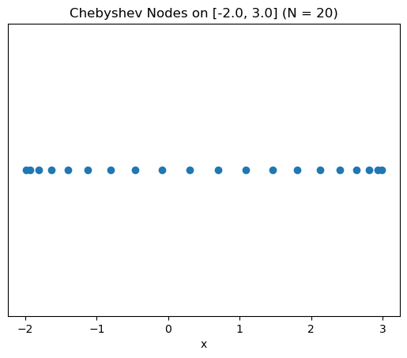

```python
import numpy as np
import matplotlib.pyplot as plt


def chebyshev_nodes(a, b, N):
    """
    Compute N Chebyshev (Gauss) nodes mapped to the interval [a, b].
    """
    k = np.arange(1, N + 1)
    x_cheb = np.cos((2 * k - 1) * np.pi / (2 * N))  # nodes on [-1, 1]
    return 0.5 * (b - a) * x_cheb + 0.5 * (a + b)


# Parameters
a, b = -2.0, 3.0
N = 20

# Compute nodes
nodes = chebyshev_nodes(a, b, N)

# Plot
plt.figure()
plt.plot(nodes, np.zeros_like(nodes), "o")
plt.xlabel("x")
plt.yticks([])
plt.title(f"Chebyshev Nodes on [{a}, {b}] (N = {N})")
plt.show()
```

##### 5.3.1.3 Connection to Fourier (The Mapping)

Chebyshev interpolation is actually just Fourier interpolation in disguise. Let $x = \cos \theta$. If we interpolate $f(x)$ on $[-1, 1]$, it is equivalent to interpolating $g(\theta) = f(\cos \theta)$ on $[0, \pi]$.

Since $g(\theta)$ is even and periodic (symmetric reflection), we can use a Fourier Cosine Series:

$$f(x) \approx \sum_{k=0}^N c_k T_k(x) \quad \longleftrightarrow \quad g(\theta) \approx \sum_{k=0}^N c_k \cos(k\theta)$$

**The Algorithm:**

- Map physical grid $x$ to angle $\theta = \arccos x$.
- Use Fast Cosine Transform (FCT) (a variant of FFT) to get coefficients $c_k$.
- Interpolate by summing the series at new points.

#### 5.3.2 Legendre Interpolation

While Chebyshev is excellent for general functions on intervals, Legendre Polynomials ($P_n(x)$) arise naturally in spherical geometries (e.g., climate modeling, quantum mechanics) due to the Laplacian operator in spherical coordinates.

##### 5.3.2.1 Orthogonality Comparison

Spectral methods rely on orthogonality: $\langle \phi_n, \phi_m \rangle = \delta_{nm}$.

**Chebyshev:**

$$\int_{-1}^1 T_n(x) T_m(x) \frac{dx}{\sqrt{1-x^2}} = \frac{\pi}{2} \delta_{nm}$$

- **Pros:** Can use FFT (via cosine transform).
- **Cons:** The weight $\frac{1}{\sqrt{1-x^2}}$ is singular at the endpoints.

**Legendre:**

$$\int_{-1}^1 P_n(x) P_m(x) dx = \frac{2}{2n+1} \delta_{nm}$$

- **Pros:** Weight is $1$. Ideal for calculating volumes/mass.
- **Cons:** No simple trigonometric identity, so No FFT. Calculation is $O(N^2)$, not $O(N \log N)$.

**Use cases:**

- *Multipole Expansion:* The potential of a charge distribution is expanded in terms of Legendre Polynomials ($1/r$, $\cos\theta/r^2$, etc.).
- *Hydrogen Atom:* The angular part of the wavefunction (Spherical Harmonics $Y_{l}^m$) is built from Legendre Polynomials. We must use them because the space is spherical.

#### 5.3.3 Summary

| Feature | Fourier | Chebyshev | Legendre |
| --- | --- | --- | --- |
| Domain | Periodic $[0, 2\pi]$ | Bounded $[-1, 1]$ | Bounded $[-1, 1]$ (Sphere) |
| Grid Points | Equispaced | Clustered at edges | Clustered at edges |
| Basis | $e^{ikx}$ | $\cos(n \arccos x)$ | Polynomials $P_n(x)$ |
| Fast Algo? | FFT ($N \log N$) | FCT ($N \log N$) | No ($N^2$ usually) |
| Convergence | Spectral (Exponential) | Spectral (Exponential) | Spectral (Exponential) |

**Takeaway:**

- If data repeats: Pad with Zeros (Fourier).
- If data has boundaries: Cluster the Grid (Chebyshev).

### 5.3.4 Examples

**Bounded Interpolation (Chebyshev vs. Equispaced)**

This solves Runge's Phenomenon. We compare fitting a polynomial to the function $f(x) = \frac{1}{1 + 25x^2}$ using equispaced points versus Chebyshev nodes.

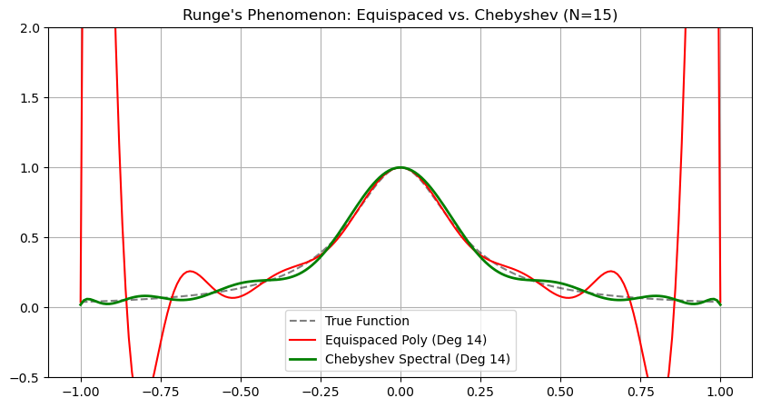

```python
import numpy as np
import matplotlib.pyplot as plt
from numpy.polynomial import Chebyshev, Polynomial


# The "Runge Function" - notoriously hard for polynomials to fit
def runge_func(x):
    return 1 / (1 + 25 * x**2)


# Number of nodes
N = 15

# 1. Equispaced Grid (The Wrong Way)
x_eq = np.linspace(-1, 1, N)
y_eq = runge_func(x_eq)
# Fit standard polynomial (power basis)
p_eq = Polynomial.fit(x_eq, y_eq, N - 1)

# 2. Chebyshev Grid (The Spectral Way)
# Roots of T_N(x) are clustered at the edges
nodes_cheb = np.cos((2 * np.arange(1, N + 1) - 1) / (2 * N) * np.pi)
y_cheb = runge_func(nodes_cheb)
# Fit Chebyshev polynomial
p_cheb = Chebyshev.fit(nodes_cheb, y_cheb, N - 1)

# Visualization
x_plot = np.linspace(-1, 1, 200)

plt.figure(figsize=(10, 5))
plt.plot(x_plot, runge_func(x_plot), "k--", alpha=0.5, label="True Function")
plt.plot(x_plot, p_eq(x_plot), "r-", label=f"Equispaced Poly (Deg {N-1})")
plt.plot(
    x_plot, p_cheb(x_plot), "g-", linewidth=2, label=f"Chebyshev Spectral (Deg {N-1})"
)

plt.ylim(-0.5, 2.0)
plt.title(f"Runge's Phenomenon: Equispaced vs. Chebyshev (N={N})")
plt.legend()
plt.grid(True)
plt.show()
```

**Using scipy directly**

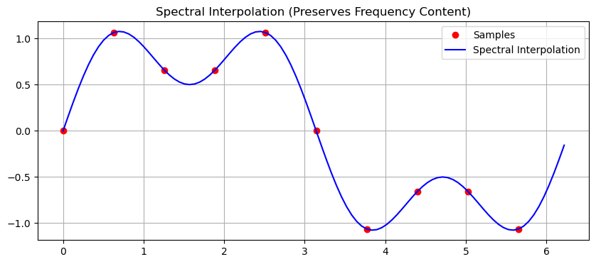

```python
# Using scipy directly
from scipy import signal

# 1. Generate Periodic Data
N_samples = 10
t = np.linspace(0, 2*np.pi, N_samples, endpoint=False)
y = np.sin(t) + 0.5 * np.sin(3*t)

# 2. Resample using Fourier Method (Spectral Interpolation)
t_dense = np.linspace(0, 2*np.pi, 100, endpoint=False)
y_dense_spectral = signal.resample(y, 100)

# 3. Plot
plt.figure(figsize=(10, 4))
plt.plot(t, y, 'ro', label='Samples')
plt.plot(t_dense, y_dense_spectral, 'b-', label='Spectral Interpolation')
plt.title("Spectral Interpolation (Preserves Frequency Content)")
plt.grid(True); plt.legend()
```

## 6. Gaussian Process Regression as Interpolation

**Interpolation with Uncertainty.**

Instead of assuming a specific function form (line, parabola), we assume the points are correlated.

- **Kernel ($k$):** Defines how much point $x_1$ influences point $x_2$.
- Common Kernel (RBF): Points close together should have similar values. $$ k(x, x') = \sigma^2 \exp\left( -\frac{(x-x')^2}{2l^2} \right) $$

This allows us to predict the value *and* the error bar between points.

### 6.1 Introduction: The Problem of Interpolation

Imagine you have a set of observed data points, $D = \{(x_i, y_i)\}_{i=1}^N$. You want to **predict** the value $y_*$ at a new, unobserved location $x_*$.

There are many ways to do this:

1. Polynomial Interpolation: Fits perfectly, but oscillates wildly (Runge's phenomenon).
2. Splines: Smooth, but they don't inherently tell you how confident they are in the prediction.
3. Linear Regression: Assuming a straight line is often too rigid.

*Gaussian Process Regression (GPR)*, historically known in geostatistics as "Kriging", offers a powerful alternative. It doesn't just give you a prediction; it gives you a probability distribution over the prediction. It tells you the mean value (the best guess) and the variance (the uncertainty).

### 6.2 The Core Concept: The Function-Space View

Let's begin with establishing intuition. In standard regression, we usually define parameters $w$ (e.g., slope and intercept) and assume a prior distribution on those parameters.

In GPR, we take the *Function-Space View*. Instead of betting on parameters, we place a prior directly on the function $f(x)$ itself. We assume the function is a random sample from a distribution of functions.

**Definition of a Gaussian Process**

A Gaussian Process is a collection of random variables, any finite number of which have a joint Gaussian distribution.

A GP is completely specified by two things:

1. Mean function $m(x) = \mathbb{E}[f(x)]$ (often assumed to be 0 for simplicity).
2. Covariance function (Kernel) $k(x, x') = \mathbb{E}[(f(x) - m(x))(f(x') - m(x'))]$.

We write:

$$f(x) \sim \mathcal{GP}(m(x), k(x, x'))$$

**The Kernel: Encoding Similarity**

The kernel is the secret sauce. It defines the properties of the function (smoothness, periodicity, etc.). It is this kernel that defines the covariance matrix of the GP, and so the distribution of random variables generated by that process is now a multivariate Gaussian with some mean vector and the aforementioned covariance matrix.

It is also up to us to choose the functional form of this kernel. The most common choice is the Squared Exponential (SE) or RBF kernel:

$$k(x, x') = \sigma_f^2 \exp\left( - \frac{(x - x')^2}{2\ell^2} \right)$$

- If $x$ is close to $x'$, $k(x, x') \approx \sigma_f^2$ (high correlation).
- If $x$ is far from $x'$, $k(x, x') \approx 0$ (no correlation).
- $\ell$ is the Length-scale: How strictly the function can wiggle.

### 6.3 The Mathematical Machinery: Multivariate Gaussians

Now that we have our concept (GPs), we need the mathematical tools to manipulate them. The building block is the *Multivariate Gaussian Distribution*. Recall that this is the distribution we assume our collection of random variables follow.

A random vector $\mathbf{y} \in \mathbb{R}^N$ follows a multivariate Gaussian distribution if its probability density function is:

$$p(\mathbf{y}) = \mathcal{N}\left(\mathbf{\mu}, \Sigma\right) = \frac{1}{(2\pi)^{N/2} |\Sigma|^{1/2}} \exp\left( -\frac{1}{2} (\mathbf{y} - \mathbf{\mu})^T \Sigma^{-1} (\mathbf{y} - \mathbf{\mu}) \right)$$

Where:

- $\mathbf{\mu}$ is the *Mean Vector*.
- $\Sigma$ is the *Covariance Matrix* (symmetric and positive definite).

**The Conditioning Theorem (The Heart of GPR)**

This is the most critical bit. Let us say that we have a random vector that follows a multivariate Gaussian distribution probability density function: $\mathbf{y}\sim\mathcal{N}\left(\mathbf{\mu}, \Sigma\right)$. And we partition that vector into two vectors, such that **we have, by construction, a joint Gaussian distribution over those two vectors, $\mathbf{y}_B$ and $\mathbf{y}_A$**:

$$\begin{bmatrix} \mathbf{y}_B \\ \mathbf{y}_A \end{bmatrix} \sim \mathcal{N}\left( \underbrace{\begin{bmatrix} \mathbf{\mu}_B \\ \mathbf{\mu}_A \end{bmatrix}}_{\mathbf{\mu}}, \underbrace{\begin{bmatrix} \Sigma_{BB} & \Sigma_{BA} \\ \Sigma_{AB} & \Sigma_{AA} \end{bmatrix}}_{\mathbf{\Sigma}} \right)$$

**Theorem**: The conditional distribution $p(\mathbf{y}_A | \mathbf{y}_B)$ is also Gaussian:

$$p(\mathbf{y}_A | \mathbf{y}_B) = \mathcal{N}(\mathbf{\mu}_{A|B}, \Sigma_{A|B})$$

Using standard Gaussian conditioning identities (derived via the Schur Complement of the block matrix), we can derive the mean and covariance of the probability density function for this conditional distribution $p(\mathbf{y}_A | \mathbf{y}_B)$:

1. **The Conditional Mean**: $$\mathbf{\mu}_{A|B} = \mathbf{\mu}_A + \Sigma_{AB} \Sigma_{BB}^{-1} (\mathbf{y}_B - \mathbf{\mu}_B)$$ *Interpretation*: Start with the prior mean of A, and adjust it based on the error of B, weighted by the correlation between A and B.
2. **The Conditional Covariance**: $$\Sigma_{A|B} = \Sigma_{AA} - \Sigma_{AB} \Sigma_{BB}^{-1} \Sigma_{BA}$$ *Interpretation*: Start with the prior uncertainty and subtract the information gained from observing B.

### 6.4 Deriving the Prediction (Noise-Free Interpolation)

- Observed Data: $X = [x_1, \dots, x_N]^T$ and $\mathbf{f} = [f(x_1), \dots, f(x_N)]^T$.
- Evaluation points: $X_*$ (dim=$M$) where we want to predict $\mathbf{f}_*$.

**Step 1: The Joint Prior** We stack our observations $\mathbf{f}$ and our unknowns $\mathbf{f}_*$ into one giant vector. Since they come from the same GP:

$$\begin{bmatrix} \mathbf{f} \\ \mathbf{f}_* \end{bmatrix} \sim \mathcal{N}\left( \mathbf{0}, \begin{bmatrix} K(X,X) & K(X, X_*) \\ K(X_*, X) & K(X_*, X_*) \end{bmatrix} \right) = \mathcal{N}\left( \mathbf{0}, \begin{bmatrix} K & K_* \\ K_*^T & K_{**} \end{bmatrix} \right)$$

Let's simplify notation. These covariance matrices are computed explicitly by evaluating the Kernel function $k(\cdot, \cdot)$ at every pair of input points:

$K = K(X,X)$: The $N \times N$ covariance matrix of training points.

$$K_{ij} = k(x_i, x_j)$$

$K_* = K(X, X_*)$: The $N \times N_*$ covariance between training and test points.

$$(K_*)_{ij} = k(x_i, x_{*j})$$

$K_{**} = K(X_*, X_*)$: The $N_* \times N_*$ covariance of test points.

$$(K_{**})_{ij} = k(x_{*i}, x_{*j})$$

Remember that the Kernel $k$ is what we chose. This is our input into this process. While the Squared Exponential (Gaussian) kernel is standard, it assumes the function is infinitely differentiable (extremely smooth). Real-world physical processes are often rougher. Common alternatives include:

- **Matérn Class Kernels**:

$$k_{Matern}(r) = \frac{2^{1-\nu}}{\Gamma(\nu)} \left( \frac{\sqrt{2\nu} r}{\ell} \right)^\nu K_\nu \left( \frac{\sqrt{2\nu} r}{\ell} \right)$$

where $r = |x - x'|$, $K_\nu$ is a *modified Bessel function*, and $\nu$ controls smoothness.

*Inspiration*: It generalizes the RBF. $\nu=1/2$ corresponds to the Ornstein-Uhlenbeck process (very jagged, continuous but nowhere differentiable). As $\nu \to \infty$, it approaches the Squared Exponential. Finite values like $\nu=3/2$ or $\nu=5/2$ are popular for modeling physical systems that are smooth but not infinitely smooth.

- **Rational Quadratic (RQ) Kernel**:

$$k_{RQ}(r) = \sigma^2 \left( 1 + \frac{r^2}{2\alpha \ell^2} \right)^{-\alpha}$$

*Inspiration*: This can be viewed as an infinite sum (scale mixture) of *Squared Exponential kernels* with different length-scales. It is perfect for data with variations at multiple scales (e.g., small ripples on top of large waves).

**Step 2: Conditioning on Data** We apply the Conditioning Theorem:

- $\mathbf{y}_A = \mathbf{f}_*$ (Unknowns)
- $\mathbf{y}_B = \mathbf{f}$ (Knowns)
- $\Sigma_{BB} = K$

**The Result:**

1. Predicted Mean (Interpolation): $$\mathbf{\bar{f}_*} = K_*^T K^{-1} \mathbf{f}$$
2. Predicted Variance (Uncertainty): $$\mathbb{V}[\mathbf{f}_*] = K_{**} - K_*^T K^{-1} K_*$$

### 6.5 Result: The Explicit Form

The matrix formulas above are elegant, but what do they actually mean? Let's expand the predictive mean equation to see the geometry of the solution.

Let's define a weight vector $\mathbf{\alpha} \in \mathbb{R}^N$:

$$\mathbf{\alpha} = K^{-1} \mathbf{f}$$

Note that $\mathbf{\alpha}$ depends only on the training data and can be pre-computed.

The predictive mean $\bar{f}(x_*)$ for any single new input $x_*$ becomes:

$$\bar{f}(x_*) = \sum_{i=1}^N \alpha_i k(x_i, x_*)$$

**Key Insight:** The GPR **mean** prediction is simply a linear combination of kernel functions centered at the training points.

- We place a little "bell curve" (or kernel shape) at every data point $x_i$.
- We scale the height of that curve by $\alpha_i$.
- We sum them up to get the final smooth curve.

### 6.6 Extending to Real Data: Noisy Regression

In the real world, data isn't perfect. We usually have $y = f(x) + \epsilon$, where $\epsilon \sim \mathcal{N}(0, \sigma_n^2)$. We don't want to interpolate the noise; we want to smooth through it.

**The Covariance Update:** The noise adds to the diagonal of the observation covariance matrix:

$$\text{cov}(\mathbf{y}) = K(X, X) + \sigma_n^2 I$$

**The Final GPR Regression Equations:** We simply replace $K$ with $(K + \sigma_n^2 I)$ in our previous formulas.

1. **Predictive Mean:** $$\bar{\mathbf{f}}_* = K_*^T (K + \sigma_n^2 I)^{-1} \mathbf{y}$$
2. **Predictive Variance:** $$\mathbb{V}[\mathbf{f}_*] = K_{**} - K_*^T (K + \sigma_n^2 I)^{-1} K_*$$

This addition of $\sigma_n^2 I$ acts exactly like *Tikhonov Regularization*. It ensures the matrix is invertible and prevents the function from oscillating wildly to hit every single noisy data point.

### 6.7 Summary

Gaussian Process Regression is a mathematically elegant framework that connects local similarity to global prediction.

1. **The Prior:** We assume functions are drawn from a Gaussian Process defined by a Kernel.
2. **The Math:** We treat data as a partial realization of a high-dimensional Gaussian.
3. **The Inference:** We use conditioning to "slice" the distribution at our data points.
4. **The Outcome:** We get a rigorous uncertainty estimate for every prediction, and the best-fit curve is a weighted sum of kernels centered at the data.

### 6.8 Hands-on: Implementing GPR from scratch

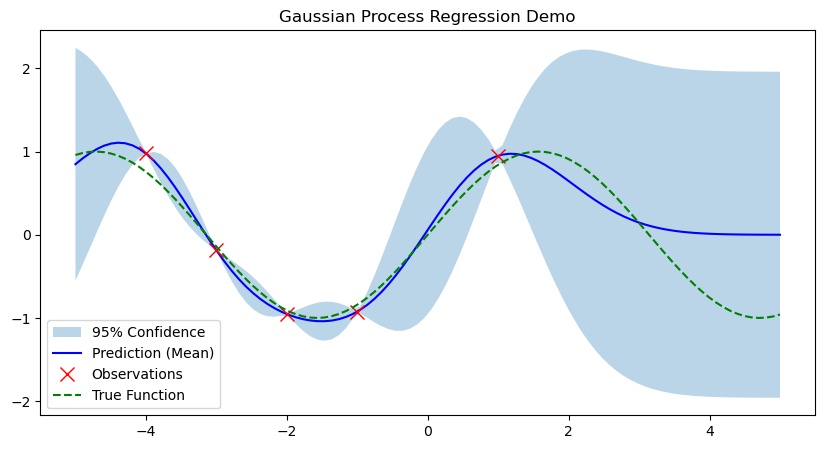

```python
import numpy as np
import matplotlib.pyplot as plt


def kernel(X1, X2, l=1.0, sigma_f=1.0):
    """
    Isotropic Squared Exponential Kernel (RBF).

    Args:
        X1: Array of m points (m x d)
        X2: Array of n points (n x d)
        l: Length-scale
        sigma_f: Vertical variation

    Returns:
        (m x n) covariance matrix
    """
    # Computes squared Euclidean distance between every pair of points
    sqdist = (
        np.sum(X1**2, 1).reshape(-1, 1) + np.sum(X2**2, 1) - 2 * np.dot(X1, X2.T)
    )
    return sigma_f**2 * np.exp(-0.5 / l**2 * sqdist)


def posterior(X_s, X_train, Y_train, l=1.0, sigma_f=1.0, sigma_y=1e-8):
    """
    Computes the posterior mean and covariance for test points X_s.

    Corresponds to GPR equations:
    mu = K_*^T (K + sigma_n^2 I)^-1 y
    cov = K_** - K_*^T (K + sigma_n^2 I)^-1 K_*
    """
    # 1. Compute Kernel Matrices
    K = kernel(X_train, X_train, l, sigma_f)  # K
    K_s = kernel(X_train, X_s, l, sigma_f)  # K_* (Train vs Test)
    K_ss = kernel(X_s, X_s, l, sigma_f)  # K_** (Test vs Test)

    # 2. Add noise to diagonal (K + sigma_n^2 I)
    K_inv = np.linalg.inv(K + sigma_y**2 * np.eye(len(X_train)))

    # 3. Compute Mean: mu = K_*^T * K_inv * y
    # Note: K_s is (N_train x N_test), so we transpose it to get (N_test x N_train)
    mu_s = K_s.T.dot(K_inv).dot(Y_train)

    # 4. Compute Covariance: cov = K_** - K_*^T * K_inv * K_*
    cov_s = K_ss - K_s.T.dot(K_inv).dot(K_s)

    return mu_s, cov_s


# --- Interp Usage ---

# Generate Noisy Data (Sine wave)
X_train = np.array([-4, -3, -2, -1, 1]).reshape(-1, 1)
Y_train = np.sin(X_train) + np.random.normal(0, 0.1, X_train.shape)

# Test points (where we want to interpolate)
X_test = np.linspace(-5, 5, 100).reshape(-1, 1)

# Run GPR
mean_prediction, covariance_matrix = posterior(X_test, X_train, Y_train)
uncertainty = 1.96 * np.sqrt(np.diag(covariance_matrix))  # 95% Confidence Interval

# Plotting
plt.figure(figsize=(10, 5))
plt.fill_between(
    X_test.ravel(),
    mean_prediction.ravel() - uncertainty,
    mean_prediction.ravel() + uncertainty,
    alpha=0.3,
    label="95% Confidence",
)
plt.plot(X_test, mean_prediction, "b-", label="Prediction (Mean)")
plt.plot(X_train, Y_train, "rx", ms=10, label="Observations")
plt.plot(X_test, np.sin(X_test), "g--", label="True Function")
plt.legend()
plt.title("Gaussian Process Regression Demo")
plt.show()
```

## 7. Extrapolation: Richardson's Trick

**Extrapolation is dangerous.** Predicting the future based on the past usually fails.

However, **Richardson Extrapolation** is a brilliant numerical trick to improve accuracy for derivatives and integrals.

**The Idea:** If we calculate a derivative $D(h)$ with step size $h$, the error often looks like: $$ D(h) = D_{true} + C h^n + O(h^{n+1}) $$

We compute $D(h)$ and $D(h/2)$. We can solve for $C$ and eliminate the error term! $$ D_{better} = \frac{2^n D(h/2) - D(h)}{2^n - 1} $$

If you have ever looked at a stock market chart or a weather trend and tried to draw a straight line into the future, you know this. Predicting the behavior of a system outside the range of known data points is usually a recipe for disaster.

However, in Numerical Analysis, we have a specific kind of "magic" called Richardson Extrapolation. It is not about predicting the future of a chaotic system; it is about exploiting the predictable structure of error to find the truth hidden within an approximation.

Today, we will derive exactly how this trick works, apply it to numerical differentiation, and see how it births entirely new integration methods like Romberg Integration.

### 7.1 The General Idea

Suppose we want to compute a quantity $L$ (the "Limit" or true value). This could be an integral $\int f(x) dx$ or a derivative $f'(x)$.

We cannot compute $L$ directly, but we have a numerical method $\phi(h)$ that approximates $L$ based on a step size $h$.

$$\lim_{h \to 0} \phi(h) = L$$

#### The Error Expansion

For many numerical methods, if the function is sufficiently smooth, the error is not random. It follows a power series in $h$. A method is of order $p$ if the dominant error term behaves like $h^p$.

Mathematically, we can often expand the approximation as:

$$\phi(h) = L + c_1 h^p + c_2 h^{p+q} + O(h^{p+q+r})$$

where:

- $L$ is the true value we want.
- $c_1, c_2, \dots$ are unknown constants depending on the function derivatives.
- $p$ is the order of the method (e.g., $p=1$ for Euler, $p=2$ for Trapezoidal).

The goal: We want to find $L$. We don't care about $c_1$. Can we use algebra to kill $c_1$?

### 7.2 Derivation of the Richardson Formula

Let's assume the error is dominated by the first term. We neglect higher-order terms for a moment:

$$\phi(h) \approx L + c_1 h^p \quad \text{--- (Equation 1)}$$

This equation has two unknowns: $L$ (which we want) and $c_1$ (which we hate). One equation is not enough.

**The Trick:** Compute the approximation again, but use a step size of $\frac{h}{2}$. Substituting $\frac{h}{2}$ into our error model:

$$\phi\left(\frac{h}{2}\right) \approx L + c_1 \left(\frac{h}{2}\right)^p$$

$$\phi\left(\frac{h}{2}\right) \approx L + c_1 \frac{h^p}{2^p} \quad \text{--- (Equation 2)}$$

Now we have a system of two linear equations with two unknowns ($L$ and $c_1 h^p$). Let's solve for $L$.

From (Equation 1), we know that $c_1 h^p \approx \phi(h) - L$. Substitute this into (Equation 2):

$$\phi\left(\frac{h}{2}\right) \approx L + \frac{1}{2^p} (\phi(h) - L)$$

Multiply by $2^p$ to clear the fraction:

$$2^p \phi\left(\frac{h}{2}\right) \approx 2^p L + \phi(h) - L$$

Group the $L$ terms:

$$2^p \phi\left(\frac{h}{2}\right) - \phi(h) \approx L(2^p - 1)$$

Solve for $L$:

$$L \approx \frac{2^p \phi(h/2) - \phi(h)}{2^p - 1}$$

This is the **Richardson Extrapolation Formula**.

#### Why is this better?

Let's define this new estimate as $\psi(h)$. By combining $\phi(h)$ and $\phi(h/2)$, we killed the $h^p$ term. The remaining error now comes from the next term in the series ($h^{p+q}$).

$$\text{Error}(\psi(h)) = O(h^{p+q})$$

We turned an order $p$ method into an order $p+q$ method just by doing a little algebra. You might object: "Wait, we have to run the simulation twice (once for $h$, once for $h/2$). Isn't that more expensive?" Yes, the computational cost increases (roughly $3\times$ for methods where halving the step doubles the work). However, the accuracy gain (error reduction) is often $100\times$ (for $h=10^{-2}$) or $1000\times$ (for $h=10^{-3}$). To achieve that same precision with the original low-order method, you might need to decrease $h$ so drastically that the runtime increases by a factor of 100 or more. The "algebra" saves us from brute-forcing the problem.

### 7.3 Application: Numerical Differentiation

Let's apply this to the Central Difference Formula for the derivative of a function $f(x)$.

The formula is:

$$D(h) = \frac{f(x+h) - f(x-h)}{2h}$$

#### Step 1: Analyze the Error

We use Taylor Series expansions for $f(x+h)$ and $f(x-h)$:

$$f(x+h) = f(x) + hf'(x) + \frac{h^2}{2}f''(x) + \frac{h^3}{6}f'''(x) + \frac{h^4}{24}f^{(4)}(x) + \dots$$

$$f(x-h) = f(x) - hf'(x) + \frac{h^2}{2}f''(x) - \frac{h^3}{6}f'''(x) + \frac{h^4}{24}f^{(4)}(x) - \dots$$

Subtracting these two:

$$f(x+h) - f(x-h) = 2hf'(x) + \frac{2h^3}{6}f'''(x) + \frac{2h^5}{120}f^{(5)}(x) + \dots$$

Divide by $2h$ to get our approximation $D(h)$:

$$D(h) = f'(x) + \frac{h^2}{6}f'''(x) + \frac{h^4}{120}f^{(5)}(x) + \dots$$

Here, $L = f'(x)$. The leading error term is $\frac{h^2}{6}f'''(x)$. Thus, the order is $p = 2$. The next error term is order 4, so $q=2$.

#### Step 2: Apply Richardson

Since $p=2$, our formula becomes:

$$D_{extrap} = \frac{2^2 D(h/2) - D(h)}{2^2 - 1} = \frac{4D(h/2) - D(h)}{3}$$

Let's see what happens if we expand this algebraically. Recall $D(h) = \frac{f(x+h) - f(x-h)}{2h}$. Therefore $D(h/2) = \frac{f(x+h/2) - f(x-h/2)}{h}$.

Substituting these into the extrapolation formula:

$$D_{extrap} = \frac{4 \left[ \frac{f(x+h/2) - f(x-h/2)}{h} \right] - \left[ \frac{f(x+h) - f(x-h)}{2h} \right]}{3}$$

Find a common denominator ($2h$) for the numerator terms:

$$D_{extrap} = \frac{ \frac{8f(x+h/2) - 8f(x-h/2)}{2h} - \frac{f(x+h) - f(x-h)}{2h} }{3}$$

$$D_{extrap} = \frac{-f(x+2\delta) + 8f(x+\delta) - 8f(x-\delta) + f(x-2\delta)}{12\delta}$$

(where $\delta = h/2$)

This result is actually the standard five-point stencil for the derivative! We derived a higher-order finite difference formula purely by combining lower-order estimates.

The error of this new estimate is $O(h^4)$.

### 7.4 Application: Romberg Integration

Richardson Extrapolation is most famous for its application to the Trapezoidal Rule for integration. This specific combination is called Romberg Integration.

We want to calculate $I = \int_a^b f(x) dx$. The Trapezoidal Rule $T(h)$ has an error expansion given by the Euler-Maclaurin Summation Formula:

$$T(h) = I + c_1 h^2 + c_2 h^4 + c_3 h^6 + \dots$$

Notice the error contains only even powers of $h$. Here $p=2$, and the next term is $p+q = 4$.

#### Level 1 Extrapolation (Simpson's Rule)

We apply the standard formula with $p=2$:

$$R_{1} = \frac{4 T(h/2) - T(h)}{3}$$

Remarkably, this linear combination of Trapezoidal rules is mathematically identical to Simpson's 1/3 Rule.

- Trapezoidal Rule fits straight lines (linear).
- Simpson's Rule fits parabolas (quadratic).
- Extrapolation effectively "cancels out" the linear error, leaving the higher-order behavior.

#### Repeated Extrapolation (The Romberg Table)

Since the error expansion of $T(h)$ has terms $h^2, h^4, h^6 \dots$, we don't have to stop after one step.

1. Calculate $T(h)$ and $T(h/2)$. Combine them to kill $h^2$. Result is $O(h^4)$.
2. Calculate $T(h/4)$. Combine with $T(h/2)$ to kill $h^2$. Result is $O(h^4)$.
3. Combine the two $O(h^4)$ results to kill the $h^4$ term!

The general recursive formula for a Romberg Table element $R_{j,k}$ (where $j$ is the row/step-size index and $k$ is the order of extrapolation):

$$R_{j,k} = \frac{4^k R_{j, k-1} - R_{j-1, k-1}}{4^k - 1}$$

This allows us to get extremely high-precision integrals (like $O(h^{10})$) using only simple Trapezoidal calculations.

### 7.5 Summary

Richardson Extrapolation is a "free lunch" in numerical analysis, provided your function is smooth.

1. Compute a low-quality approximation with step $h$.
2. Compute another low-quality approximation with step $h/2$.
3. Linearly combine them to cancel the leading error term.
4. Repeat to eliminate higher-order terms.

It turns computing power into accuracy without requiring new, complex formulas.

### 7.6 Examples

```
--- Part 1: Differentiation Visualization ---
Function: f(x) = e^x * sin(x) over [0, 2π]
Plotting error comparison...
```

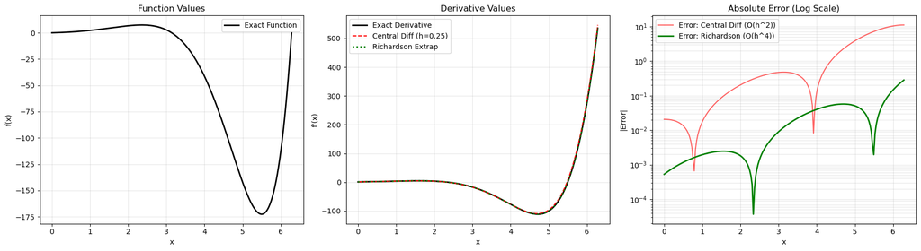

```python
import numpy as np
import matplotlib.pyplot as plt


def richardson_extrapolation(estimate_h, estimate_h2, p):
    """
    Computes the Richardson Extrapolation estimate.

    Args:
        estimate_h: The approximation using step size h.
        estimate_h2: The approximation using step size h/2.
        p: The order of the error term to eliminate (O(h^p)).

    Returns:
        The improved approximation with error O(h^(p+q)).
    """
    return (2**p * estimate_h2 - estimate_h) / (2**p - 1)


# ==========================================
# PART 1: NUMERICAL DIFFERENTIATION
# ==========================================


def central_difference(f, x, h):
    """Computes the central difference approximation of f'(x)."""
    return (f(x + h) - f(x - h)) / (2 * h)


def demo_differentiation_plot():
    print("\n--- Part 1: Differentiation Visualization ---")
    print("Function: f(x) = e^x * sin(x) over [0, 2π]")
    print("Plotting error comparison...")

    # Define function using numpy for array handling
    def func(x):
        return np.exp(x) * np.sin(x)

    def deriv_true(x):
        return np.exp(x) * (np.sin(x) + np.cos(x))

    # Generate a range of points
    x = np.linspace(0, 2*np.pi, 200)
    exact_val = deriv_true(x)

    # Step 1: Compute approximations with h and h/2
    h = 0.5
    D_h = central_difference(func, x, h)
    D_h2 = central_difference(func, x, h / 2)

    # Step 2: Apply Richardson Extrapolation (p=2 for Central Diff)
    D_extrap = richardson_extrapolation(D_h, D_h2, p=2)

    # Calculate errors
    error_standard = np.abs(D_h2 - exact_val)
    error_richardson = np.abs(D_extrap - exact_val)

    # Plotting
    plt.figure(figsize=(18, 5))

    # Subplot 2: The Function values
    plt.subplot(1, 3, 1)
    plt.plot(x, func(x), "k-", lw=2, label="Exact Function")
    plt.title("Function Values")
    plt.xlabel("x")
    plt.ylabel("f(x)")
    plt.legend()
    plt.grid(True, alpha=0.3)

    # Subplot 1: The Derivative values
    plt.subplot(1, 3, 2)
    plt.plot(x, exact_val, "k-", lw=2, label="Exact Derivative")
    plt.plot(x, D_h2, "r--", label=f"Central Diff (h={h/2})")
    plt.plot(x, D_extrap, "g:", lw=2, label="Richardson Extrap")
    plt.title("Derivative Values")
    plt.xlabel("x")
    plt.ylabel("f'(x)")
    plt.legend()
    plt.grid(True, alpha=0.3)

    # Subplot 2: The Error (Log Scale)
    plt.subplot(1, 3, 3)
    plt.semilogy(
        x, error_standard, "r-", alpha=0.6, label=f"Error: Central Diff (O(h^2))"
    )
    plt.semilogy(x, error_richardson, "g-", lw=2, label="Error: Richardson (O(h^4))")
    plt.title("Absolute Error (Log Scale)")
    plt.xlabel("x")
    plt.ylabel("|Error|")
    plt.legend()
    plt.grid(True, alpha=0.3, which="both")

    plt.tight_layout()
    plt.show()

demo_differentiation_plot()
```

```
--- Part 2: Romberg Integration Visualization ---
Function: f(x) = 4 / (1 + x^2) integrated from 0 to 1
Generating convergence plot...

Computing Romberg Table (7x7)...
Final Result (R_6,6): 3.141592653589723
Exact Value:          3.141592653589793
```

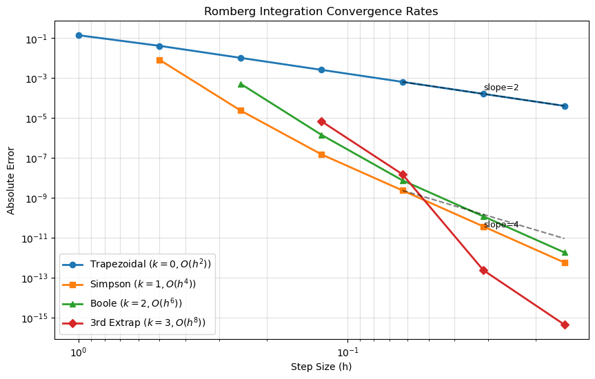

```python
# ==========================================
# PART 2: ROMBERG INTEGRATION
# ==========================================


def trapezoidal_rule(f, a, b, n):
    """Computes the composite trapezoidal rule for n intervals."""
    h = (b - a) / n
    # Create x points
    x = np.linspace(a, b, n + 1)
    y = f(x)
    # Trapezoidal sum: h * (0.5*f(a) + f(x_1) + ... + f(x_{n-1}) + 0.5*f(b))
    total = np.sum(y) - 0.5 * y[0] - 0.5 * y[-1]
    return h * total


def demo_romberg_integration_plot():
    r"""
    \section*{Romberg Integration Visualization}

    \textbf{Purpose.} Visualize convergence of Romberg integration applied to
    the integral
    \[
        I = \int_a^b f(x)\,dx,
    \]
    for the test function \(f(x)=\dfrac{4}{1+x^2}\) on \([0,1]\) (so the exact
    value is \(\pi\)).

    \textbf{Background.}
    The composite trapezoidal rule with step size \(h=(b-a)/n\) (with \(n\)
    subintervals) is
    \[
        T(h) = h\left(\tfrac{1}{2}f(a) + \sum_{j=1}^{n-1} f(a+jh) + \tfrac{1}{2}f(b)\right),
    \]
    and has leading error \(E_T(h)=C_2 h^2 + C_4 h^4 + \cdots\).

    Romberg integration constructs a triangular table \(R_{i,k}\) where the
    first column is trapezoidal values at \(h_i=(b-a)/2^i\):
    \[
        R_{i,0} = T(h_i),
    \]
    and higher columns use Richardson extrapolation:
    \[
        R_{i,k} = \frac{4^k R_{i,k-1} - R_{i-1,k-1}}{4^k - 1}, \qquad k\ge1.
    \]
    If the trapezoidal rule error expansion begins with \(h^2\), then the
    extrapolated values \(R_{i,k}\) have asymptotic error \(O(h^{2+2k})\).

    \textbf{What this routine does.}
    - Builds an \(m\times m\) Romberg table (here \(m=\)rows) to demonstrate
      the extrapolation levels.
    - Records absolute errors \(|R_{i,k}-I_{\text{exact}}|\) for each column
      \(k\) versus step size \(h_i\).
    - Produces a log-log plot of error vs.\ step size for the first few
      columns and overlays reference slope lines (slope 2 and slope 4) to
      visually confirm convergence orders.

    \textbf{Notes.}
    - The Richardson factor used is \(4^k\) because the trapezoidal error
      behaves like an even power series in \(h\) beginning with \(h^2\).
    - This function is strictly for demonstration/visualization and prints the
      final extrapolated result alongside the exact value.

    """
    print("\n--- Part 2: Romberg Integration Visualization ---")
    print("Function: f(x) = 4 / (1 + x^2) integrated from 0 to 1")
    print("Generating convergence plot...")

    def func(x):
        return 4.0 / (1.0 + x**2)

    a, b = 0.0, 1.0
    exact_val = np.pi

    # Increase rows to show convergence trends clearly
    rows = 7
    R = [[0.0] * rows for _ in range(rows)]
    h_values = []  # Track step sizes

    # Data storage for plotting
    # errors_by_col[k] will store the list of errors for the k-th column of the Romberg table
    errors_by_col = [[] for _ in range(rows)]
    h_by_col = [[] for _ in range(rows)]

    print(f"\nComputing Romberg Table ({rows}x{rows})...")

    for i in range(rows):
        n_intervals = 2**i
        current_h = (b - a) / n_intervals
        h_values.append(current_h)

        # 1. Standard Trapezoidal Rule (Column 0)
        R[i][0] = trapezoidal_rule(func, a, b, n_intervals)

        # Store error for Col 0
        errors_by_col[0].append(abs(R[i][0] - exact_val))
        h_by_col[0].append(current_h)

        # 2. Extrapolate for columns k=1 to i
        for k in range(1, i + 1):
            factor = 4**k
            R[i][k] = (factor * R[i][k - 1] - R[i - 1][k - 1]) / (factor - 1)

            # Store error for Col k
            errors_by_col[k].append(abs(R[i][k] - exact_val))
            h_by_col[k].append(current_h)

    print(f"Final Result (R_{rows-1},{rows-1}): {R[rows-1][rows-1]:.15f}")
    print(f"Exact Value:          {exact_val:.15f}")

    # Plotting Convergence
    plt.figure(figsize=(10, 6))

    markers = ["o", "s", "^", "D", "v", ">", "<"]
    labels = [
        "Trapezoidal $(k=0, O(h^2))$",
        "Simpson $(k=1, O(h^4))$",
        "Boole $(k=2, O(h^6))$",
        "3rd Extrap $(k=3, O(h^8))$",
    ]

    # Plot the first 4 columns to keep chart readable
    for k in range(min(4, rows)):
        if len(errors_by_col[k]) > 0:
            plt.loglog(
                h_by_col[k],
                errors_by_col[k],
                marker=markers[k],
                linestyle="-",
                linewidth=2,
                label=labels[k] if k < len(labels) else f"Order k={k}",
            )

    # Add reference slope lines for visual confirmation
    # We pick a reference point based on the data to position the slope lines
    ref_h = np.array(h_by_col[0][-3:])

    # Slope 2 reference
    ref_err2 = ref_h**2 * (errors_by_col[0][-3] / ref_h[-3] ** 2)
    plt.loglog(ref_h, ref_err2, "k--", alpha=0.5)
    plt.text(ref_h[1], ref_err2[1] * 1.5, "slope=2", fontsize=9)

    # Slope 4 reference (if applicable)
    if len(errors_by_col[1]) > 3:
        ref_h4 = np.array(h_by_col[1][-3:])
        ref_err4 = ref_h4**4 * (errors_by_col[1][-3] / ref_h4[-3] ** 4)
        plt.loglog(ref_h4, ref_err4, "k--", alpha=0.5)
        plt.text(
            ref_h4[1], ref_err4[1] * 0.5, "slope=4", fontsize=9, verticalalignment="top"
        )

    plt.title("Romberg Integration Convergence Rates")
    plt.xlabel("Step Size (h)")
    plt.ylabel("Absolute Error")
    plt.grid(True, which="both", ls="-", alpha=0.4)
    plt.legend()
    plt.gca().invert_xaxis()  # Convention: smaller h (more precision) to the right
    plt.show()


demo_romberg_integration_plot()
```

```python
# Example: Numerical Derivative of sin(x) at x=1
def f(x): return np.sin(x)
x0 = 1.0
true_val = np.cos(1.0)

# Finite Difference: (f(x+h) - f(x-h)) / 2h  <-- This is O(h^2)
def diff(h): return (f(x0+h) - f(x0-h)) / (2*h)

h = 0.5
D_h = diff(h)
D_h2 = diff(h/2)

# Apply Richardson (since method is O(h^2), n=2)
# Formula: (4 * D(h/2) - D(h)) / 3
D_rich = (4 * D_h2 - D_h) / 3

print(f"True Value: {true_val:.9f}")
print(f"D(h={h}): {D_h:.9f} (Err: {abs(D_h-true_val):.9f})")
print(f"D(h={h/2}): {D_h2:.9f} (Err: {abs(D_h2-true_val):.9f})")
print(f"Richardson: {D_rich:.9f} (Err: {abs(D_rich-true_val):.9f})")
print(f"\nImprovement factor: {abs(D_h2-true_val) / abs(D_rich-true_val):.1f}x")
```

```
True Value: 0.540302306
D(h=0.5): 0.518069448 (Err: 0.022232858)
D(h=0.25): 0.534691719 (Err: 0.005610587)
Richardson: 0.540232476 (Err: 0.000069830)

Improvement factor: 80.3x
```

## 8. Discussion Questions

1. Why is Spectral Interpolation preferred for Quantum Mechanics (Wavefunctions) but Splines preferred for Thermodynamics (Equation of State tables)?
2. Why does the Gaussian Process error explode (get wide) as you move away from data points, whereas a Polynomial just shoots to infinity without warning?
3. **Implementation:** In Richardson extrapolation, what happens if $h$ gets *too* small? (Recall Lecture 1: Numerical Pitfalls).